# Lab_3

Kim Youngrae

2016년 10월 24일

# Content

- Principal component regression
- Computation
- PCA example

# Principal component regression

먼저 $y$와 $X$를 Centerizing한 회귀분석 모형을 생각한다.

$y = X\beta + \epsilon$

$X$는 $n\times p$ 행렬이고, p는 무시할수 없을만큼 크다고 가정했을 때, 우리는 $X$에 PCA를 적용하여 차원축소를 생각할 수 있다.

$X$의 Eigenvector중 $r$ 개만 꺼낸 행렬을 $E_r$이라 하면, 다음과 같이 표현할 수 있다.

$X = Z E_r^T \hspace{10mm} Z= X E_r.$

이때, $r = p$인 경우를 생각해 보면, 회귀분석 모양은 다음과 같게 된다.

$\begin{aligned} y &=X \beta + \epsilon \\ &= XE_p E_p^T \beta + \epsilon\\ &= Z \gamma + \epsilon \end{aligned}$

$\gamma = E_p^T \beta$ 가 된다.

이때 $\beta$의 LSE는 $\hat{\beta}^{LSE} = E_p \hat{\gamma}^{LSE}$로 구할 수 있다. 따라서 다음과 같이 계산할 수 있다.

$\begin{aligned} \hat{\beta}^{LSE} &= E_p \hat{\gamma}^{LSE} \\ &= E_p (Z^TZ)^{-1}Z^Ty \\ &= E_p (L^{-2}) Z^Ty \\ &= E_p (L^{-2}) E_p^T X^T y \\ &= \{\sum_{k=1}^p\frac{1}{l_k}e_ke_k^T\}X^Ty \end{aligned}$

이때 $L=diag(l_k^{-1/2})$이고, $l_k$는 $X^TX$의 eigen value이다.

이를 이용해, $\hat{\beta}^{LSE}$의 분산을 구해보면,

$\begin{aligned} Var(\hat{\beta}^{LSE}) & = \sigma^2 E_p (Z^TZ)^{-1}Z^TZ (Z^TZ)^{-1}E_p^T \\ &= \sigma^2 \sum_{k=1}^p\frac{1}{l_k}e_ke_k^T \end{aligned}$ 와 같이 구할 수 있다.

다음으로, 차원을 줄이는 경우, 즉 $r < p$ 인 경우를 생각해보면, 위에서 $p$로 적었던 것을 모두 $r$로 바꾸어 생각하면 된다.

따라서 PCR 추정량 $\tilde{\beta}$와 그의 분산은 다음과 같이 구할 수 있다.

$\begin{aligned} \tilde{\beta} &= \{\sum_{k=1}^r\frac{1}{l_k}e_ke_k^T\}X^Ty \\ Var(\tilde{\beta}) &= \sigma^2 \sum_{k=1}^r\frac{1}{l_k}e_ke_k^T \end{aligned}$

이제, 실제로 X에 PCA를 시행하여, $r=p$로 주었을 때 만들어낸 PCR 추정량과, LSE가 같은지 직접 확인해보고, $r<p$인 경우에 추정량이 어떻게 변하는지 확인해 보도록 하자.

# Computation

먼저 자료를 입력한다. 자료는 책의 Table 7-5의 자료이다.

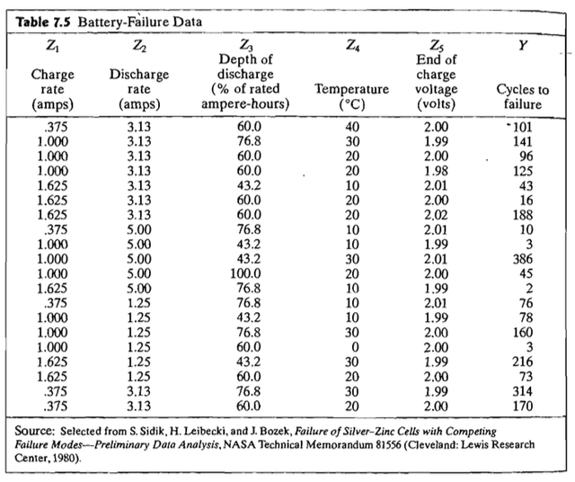

```r
data<-read.table("/Users/kyr0302/Desktop/Lab_3/T7-5.dat",header=FALSE,sep="");
colnames(data)<-c("CR","DR","Depth","Temp","Volt","Cycles")
```

PCR이 어떤 상황에서 강점을 지니는지 확인해보기 위해, 하나의 변수를 복제한 뒤, 약간의 Error를 더해줘 새로운 변수로 대입해보았다. PCA는 X가 Multicollinearity를 가질 때 강점을 가진다는 것을 예측할 수 있으므로, 이를 확인해보기 위한 절차이다.

```r
set.seed(1024)
Fake<-data$CR+rnorm(nrow(data),sd=sqrt(var(data$CR)))
data_rep<-cbind(data[,-6],Fake)
y<-data[,6]
```

위에서 여러가지 변수들이 있지만, Cycles to failure를 종속변수로 생각할것이고, 첫번쨰 변수인 Charge rate에 error를 붙여서 새로운 변수(Fake)를 만들었다. 따라서 총 6개의 독립변수를 가지며, Cycle을 종속변수로하는 회귀분석 모형을 생각할 수 있다.

```r
p=ncol(data_rep);n=nrow(data_rep)
y.cen<-y-mean(y)
X.cen<-t(t(data_rep)-colMeans(data_rep))
XtX<-cov(X.cen)*(n-1)
eig.res<-eigen(XtX)
```

위는 $X$와 $y$를 Centerizing하는 작업이다. 그리고 $X^tX$를 만들어서, 그를 eigen decomposition하였다.

이제 $r=p$인 경우에, 위에서 구했던 방법으로 $\hat{\beta}^{LSE}$를 구해보면, 다음과 같다.

```r
r=p;
Z.cen<-as.matrix(X.cen)%*%eig.res$vectors[,1:r]
gammahat=solve(t(Z.cen)%*%Z.cen)%*%t(Z.cen)%*%y.cen
gammahat
```

```
##              [,1]
## [1,]    0.8715096
## [2,]    7.1557325
## [3,]    0.8264465
## [4,]    9.3239684
## [5,]  -53.7868463
## [6,] 1226.1305249
```

이렇게 $\hat{\gamma}^{LSE}$ 를, $y=Z\gamma+\epsilon$에서의 LSE구하는 방법으로 구할 수 있다. 이러한 회귀분석은 우리가 R에서 lm이라는 함수를 이용해서 얻을 수도 있는데, 실제로 같게 구해지는지 확인해볼수 있다.

```r
lm(y.cen~.+0,data=as.data.frame(Z.cen))
```

```
##
## Call:
## lm(formula = y.cen ~ . + 0, data = as.data.frame(Z.cen))
##
## Coefficients:
##        V1         V2         V3         V4         V5         V6
##    0.8715     7.1557     0.8264     9.3240   -53.7868  1226.1305
```

이렇게 구한 $\hat{\gamma}^{LSE}$를 가지고 $\hat{\beta}^{LSE}$를 구하면 다음과 같다.

```r
betahat=eig.res$vectors[,1:r]%*%gammahat
betahat
```

```
##              [,1]
## [1,]  -41.8609824
## [2,]    0.3938161
## [3,]   -1.5729562
## [4,]    7.5717892
## [5,] 1226.4925144
## [6,]   18.2340706
```

이를 $\{\sum_{k=1}^p\frac{1}{l_k}e_ke_k^T\}X^Ty$를 이용해서 구할수도 있다.

```r
temp=matrix(0,nrow=r,ncol=r)
for(i in 1:r){
  temp=temp+(eig.res$vectors[,i]%*%t(eig.res$vectors[,i]))/(eig.res$values[i])
}
temp%*%t(X.cen)%*%y.cen
```

```
##              [,1]
## [1,]  -41.8609824
## [2,]    0.3938161
## [3,]   -1.5729562
## [4,]    7.5717892
## [5,] 1226.4925144
## [6,]   18.2340706
```

이는 $y=X\beta+\epsilon$의 LSE이므로, Z를 구하지 않고, 원래 가지고 있는 X에 lm을 적용해서도 구할 수 있다.

```r
fit<-lm(y.cen~CR+DR+Depth+Temp+Volt+Fake+0,data=as.data.frame(X.cen))
fit
```

```
##
## Call:
## lm(formula = y.cen ~ CR + DR + Depth + Temp + Volt + Fake + 0,
##     data = as.data.frame(X.cen))
##
## Coefficients:
##        CR         DR      Depth       Temp       Volt       Fake
##  -41.8610     0.3938    -1.5730     7.5718  1226.4925    18.2341
```

다음으로, $r<p$인경우에, PCR 추정량과 LSE를 비교해보도록 한다. 원래 변수가 5개였으므로, 차원을 1개만 줄여서 $r=5$인채로 PCR 추정량을 구해보면 다음과 같다. $\{\sum_{k=1}^r\frac{1}{l_k}e_ke_k^T\}X^Ty$ 을 이용하여 구해보았다.

```r
r=5
temp=matrix(0,nrow=p,ncol=p)
for(i in 1:r){
  temp=temp+(eig.res$vectors[,i]%*%t(eig.res$vectors[,i]))/(eig.res$values[i])
}
betahat.pcr<-temp%*%t(X.cen)%*%y.cen
betahat.pcr
```

```
##             [,1]
## [1,] -46.3933747
## [2,]   1.1572715
## [3,]  -1.4674495
## [4,]   7.7430433
## [5,]   0.4142452
## [6,]  28.5769847
```

PCR 추정량의 분산은 $Var(\tilde{\beta}) = \sigma^2\sum_{k=1}^r \frac{1}{l_k}e_ke_k^T$로 구할 수 있는데, 이 때 Sigma는 MSE를 사용하도록 한다. MSE를 구하기 위해, linear model을 먼저 fitting 한다.

```r
fit<-lm(y.cen~.+0,data=as.data.frame(X.cen))
MSE<-summary(fit)$sigma
```

두개의 분산을 비교해보면 다음과 같다.

```r
var.betahat.pcr<-MSE*temp
var.betahat.pcr
```

```
##              [,1]         [,2]        [,3]         [,4]         [,5]
## [1,]  26.93990697 -0.047866143  0.10730816 -0.200574196 -0.190853458
## [2,]  -0.04786614  2.284331001 -0.03290413  0.024121603  0.006654386
## [3,]   0.10730816 -0.032904128  0.02315145  0.005619300  0.001432150
## [4,]  -0.20057420  0.024121603  0.00561930  0.066868182  0.006894602
## [5,]  -0.19085346  0.006654386  0.00143215  0.006894602  0.002788576
## [6,] -10.81314997  0.599174101  0.21889440  0.726466537  0.246311426
##             [,6]
## [1,] -10.8131500
## [2,]   0.5991741
## [3,]   0.2188944
## [4,]   0.7264665
## [5,]   0.2463114
## [6,]  24.4015083
```

```r
summary(fit)$cov
```

```
##                 CR            DR         Depth          Temp         Volt
## CR     0.329530012 -0.0020997417  1.064915e-03 -2.729076e-03   2.45546416
## DR    -0.002099742  0.0274294280 -3.557629e-04  3.447462e-04  -0.41391202
## Depth  0.001064915 -0.0003557629  2.803050e-04  7.483158e-05  -0.05719503
## Temp  -0.002729076  0.0003447462  7.483158e-05  8.083541e-04  -0.09278224
## Volt   2.455464163 -0.4139120208 -5.719503e-02 -9.278224e-02 664.85304395
## Fake  -0.149353058  0.0106193860  3.086331e-03  9.424550e-03  -5.60561712
##               Fake
## CR    -0.149353058
## DR     0.010619386
## Depth  0.003086331
## Temp   0.009424550
## Volt  -5.605617118
## Fake   0.337563293
```